# Association_Rules

Nathan_Njonge

7/17/2021

## PROBLEM DEFINITION

You are a Data analyst at Carrefour Kenya and are currently undertaking a project that will inform the marketing department on the most relevant marketing strategies that will result in the highest no. of sales (total price including tax). Your project has been divided into four parts where you’ll explore a recent marketing dataset by performing various unsupervised learning techniques and later providing recommendations based on your insights.

```r
# load our dataset
df <- read.csv("http://bit.ly/SupermarketDatasetII")
```

```r
# preview the top of our dataset
head(df)
```

```
##              shrimp      almonds    avocado   vegetables.mix green.grapes
## 1           burgers    meatballs       eggs
## 2           chutney
## 3            turkey      avocado
## 4     mineral water         milk energy bar whole wheat rice    green tea
## 5    low fat yogurt
## 6 whole wheat pasta french fries
##   whole.weat.flour yams cottage.cheese energy.drink tomato.juice low.fat.yogurt
## 1
## 2
## 3
## 4
## 5
## 6
##   green.tea honey salad mineral.water salmon antioxydant.juice frozen.smoothie
## 1
## 2
## 3
## 4
## 5
## 6
##   spinach olive.oil
## 1                NA
## 2                NA
## 3                NA
## 4                NA
## 5                NA
## 6                NA
```

```r
# preview the bottom of our dataset
tail(df)
```

```
##        shrimp           almonds     avocado vegetables.mix green.grapes
## 7495 pancakes        light mayo
## 7496   butter        light mayo fresh bread
## 7497  burgers frozen vegetables        eggs   french fries    magazines
## 7498  chicken
## 7499 escalope         green tea
## 7500     eggs   frozen smoothie yogurt cake low fat yogurt
##      whole.weat.flour yams cottage.cheese energy.drink tomato.juice
## 7495
## 7496
## 7497        green tea
## 7498
## 7499
## 7500
##      low.fat.yogurt green.tea honey salad mineral.water salmon
## 7495
## 7496
## 7497
## 7498
## 7499
## 7500
##      antioxydant.juice frozen.smoothie spinach olive.oil
## 7495                                                  NA
## 7496                                                  NA
## 7497                                                  NA
## 7498                                                  NA
## 7499                                                  NA
## 7500                                                  NA
```

```r
# view the dimensions of our dataset
dim(df)
```

```
## [1] 7500   20
```

> Our dataset has 7500 rows and 20 columns.

```r
# summary of our dataset
summary(df)
```

```
##     shrimp            almonds            avocado          vegetables.mix
##  Length:7500        Length:7500        Length:7500        Length:7500
##  Class :character   Class :character   Class :character   Class :character
##  Mode  :character   Mode  :character   Mode  :character   Mode  :character
##  green.grapes       whole.weat.flour       yams           cottage.cheese
##  Length:7500        Length:7500        Length:7500        Length:7500
##  Class :character   Class :character   Class :character   Class :character
##  Mode  :character   Mode  :character   Mode  :character   Mode  :character
##  energy.drink       tomato.juice       low.fat.yogurt      green.tea
##  Length:7500        Length:7500        Length:7500        Length:7500
##  Class :character   Class :character   Class :character   Class :character
##  Mode  :character   Mode  :character   Mode  :character   Mode  :character
##     honey              salad           mineral.water         salmon
##  Length:7500        Length:7500        Length:7500        Length:7500
##  Class :character   Class :character   Class :character   Class :character
##  Mode  :character   Mode  :character   Mode  :character   Mode  :character
##  antioxydant.juice  frozen.smoothie      spinach          olive.oil
##  Length:7500        Length:7500        Length:7500        Mode:logical
##  Class :character   Class :character   Class :character   NA's:7500
##  Mode  :character   Mode  :character   Mode  :character
```

```r
# check for missing values
colSums(is.na(df))
```

```
##            shrimp           almonds           avocado    vegetables.mix
##                 0                 0                 0                 0
##      green.grapes  whole.weat.flour              yams    cottage.cheese
##                 0                 0                 0                 0
##      energy.drink      tomato.juice    low.fat.yogurt         green.tea
##                 0                 0                 0                 0
##             honey             salad     mineral.water            salmon
##                 0                 0                 0                 0
## antioxydant.juice   frozen.smoothie           spinach         olive.oil
##                 0                 0                 0              7500
```

> There appears to be missing values in the olive.oil column

```r
# omit missing values
df2 <- subset(df, select=-c(olive.oil))
colSums(is.na(df2))
```

```
##            shrimp           almonds           avocado    vegetables.mix
##                 0                 0                 0                 0
##      green.grapes  whole.weat.flour              yams    cottage.cheese
##                 0                 0                 0                 0
##      energy.drink      tomato.juice    low.fat.yogurt         green.tea
##                 0                 0                 0                 0
##             honey             salad     mineral.water            salmon
##                 0                 0                 0                 0
## antioxydant.juice   frozen.smoothie           spinach
##                 0                 0                 0
```

```r
# find any duplicated rows in our dataset
duplicated_rows <- df2[duplicated(df2),]
head(duplicated_rows)
```

```
##          shrimp almonds avocado vegetables.mix green.grapes whole.weat.flour
## 34      cookies
## 42    spaghetti
## 60    spaghetti
## 64       turkey    eggs
## 65 french fries
## 68      cookies
##    yams cottage.cheese energy.drink tomato.juice low.fat.yogurt green.tea honey
## 34
## 42
## 60
## 64
## 65
## 68
##    salad mineral.water salmon antioxydant.juice frozen.smoothie spinach
## 34
## 42
## 60
## 64
## 65
## 68
```

> There is presence of duplicated rows in our dataset

```r
# dropping duplicated items
unique_items <- df2[!duplicated(df2), ]
# view the unique items
head(unique_items)
```

```
##              shrimp      almonds    avocado   vegetables.mix green.grapes
## 1           burgers    meatballs       eggs
## 2           chutney
## 3            turkey      avocado
## 4     mineral water         milk energy bar whole wheat rice    green tea
## 5    low fat yogurt
## 6 whole wheat pasta french fries
##   whole.weat.flour yams cottage.cheese energy.drink tomato.juice low.fat.yogurt
## 1
## 2
## 3
## 4
## 5
## 6
##   green.tea honey salad mineral.water salmon antioxydant.juice frozen.smoothie
## 1
## 2
## 3
## 4
## 5
## 6
##   spinach
## 1
## 2
## 3
## 4
## 5
## 6
```

## Implementing the Solution

```r
# loading the libraries
library(arules)
```

```r
library(arulesViz)
library(tidyverse)
library(readxl)
library(knitr)
library(ggplot2)
library(lubridate)
library(plyr)
library(dplyr)
```

```r
# store this unique items into a csv
write.csv(unique_items,"D:/IP_WEEK_14/analysis.csv", quote = FALSE, row.names = FALSE)
```

```r
# convert our unique items into an object of the transaction class
tr <- read.transactions("D:/IP_WEEK_14/analysis.csv", format = 'basket', sep=',')
# View the transaction object
tr
```

```
## transactions in sparse format with
##  5176 transactions (rows) and
##  130 items (columns)
```

```r
# summary of the transaction object
summary(tr)
```

```
## transactions as itemMatrix in sparse format with
##  5176 rows (elements/itemsets/transactions) and
##  130 columns (items) and a density of 0.03902479
##
## most frequent items:
## mineral water     spaghetti          eggs     chocolate  french fries
##          1551          1188          1077          1062           997
##       (Other)
##         20384
##
## element (itemset/transaction) length distribution:
## sizes
##   1   2   3   4   5   6   7   8   9  10  11  12  13  14  15  16  18  19
## 110 757 976 804 667 493 391 324 259 139 102  67  40  22  17   4   1   3
##
##    Min. 1st Qu.  Median    Mean 3rd Qu.    Max.
##   1.000   3.000   4.000   5.073   7.000  19.000
##
## includes extended item information - examples:
##              labels
## 1           almonds
## 2 antioxydant juice
## 3 antioxydant.juice
```

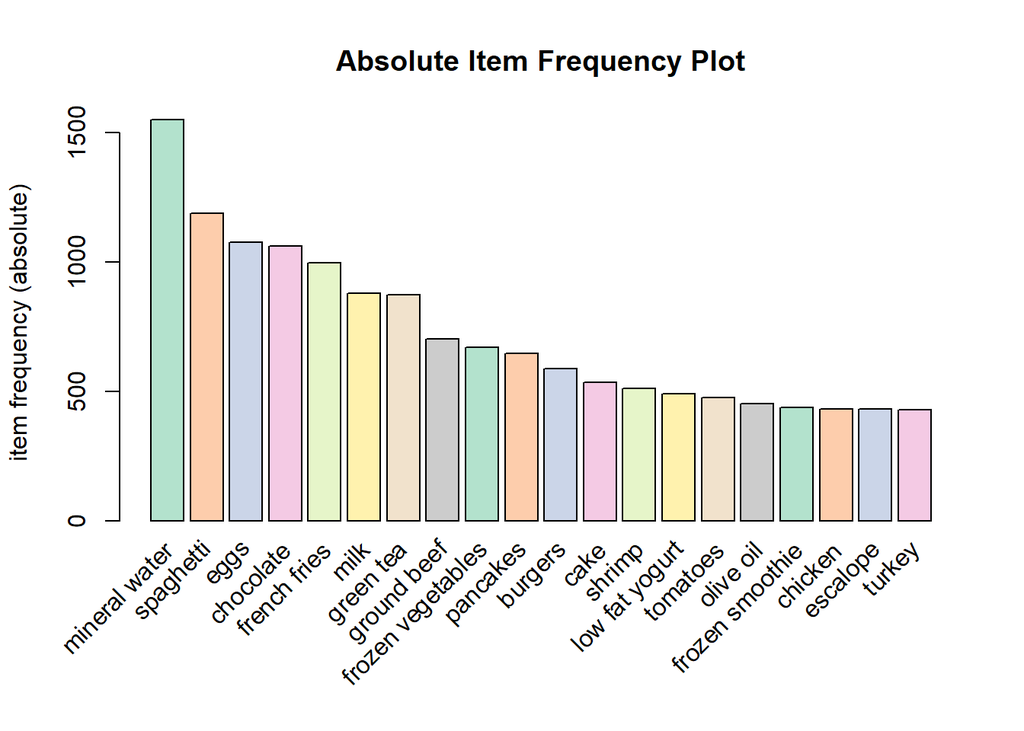

```r
# Create an item frequency plot for the top 20 items
if (!require("RColorBrewer")) {
# install color package of R
install.packages("RColorBrewer")
#include library RColorBrewer
library(RColorBrewer)
}
itemFrequencyPlot(tr,topN=20,type="absolute",col=brewer.pal(8,'Pastel2'), main="Absolute Item Frequency Plot")
```

> Our absolute item frequency plot gives us the numeric frequencies of each item independently where mineral water appears to have had the highest frequency.

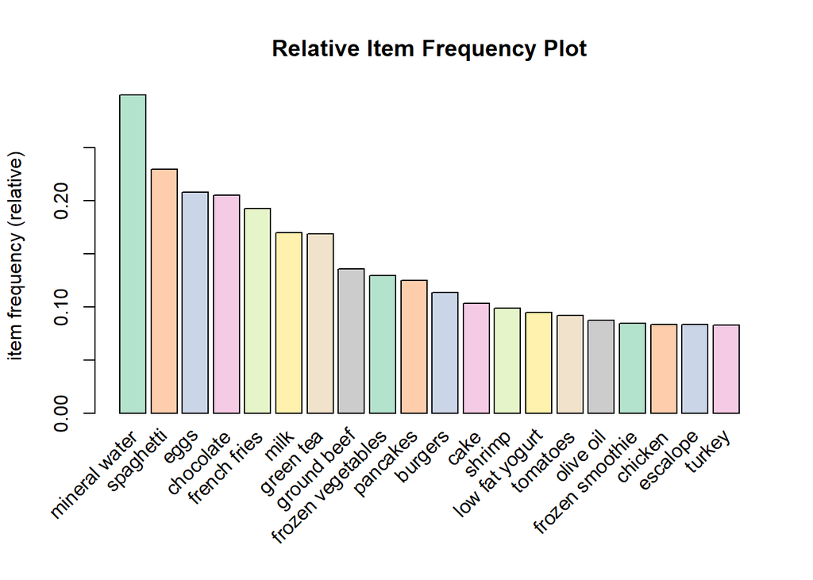

```r
# item frequency plot for the top 20 items using relative type
itemFrequencyPlot(tr,topN=20,type="relative",col=brewer.pal(8,'Pastel2'),main="Relative Item Frequency Plot")
```

> Our relative item frequency plot tells us how many times these items have appeared as compared to others, whereby mineral water has appeared more compared to the others.

## Generating Rules

```r
# Min Support as 0.001, confidence as 0.8.
association.rules <- apriori(tr, parameter = list(supp=0.001, conf=0.8,maxlen=10))
```

```
## Apriori
##
## Parameter specification:
##  confidence minval smax arem  aval originalSupport maxtime support minlen
##         0.8    0.1    1 none FALSE            TRUE       5   0.001      1
##  maxlen target  ext
##      10  rules TRUE
##
## Algorithmic control:
##  filter tree heap memopt load sort verbose
##     0.1 TRUE TRUE  FALSE TRUE    2    TRUE
##
## Absolute minimum support count: 5
##
## set item appearances ...[0 item(s)] done [0.00s].
## set transactions ...[130 item(s), 5176 transaction(s)] done [0.00s].
## sorting and recoding items ... [117 item(s)] done [0.00s].
## creating transaction tree ... done [0.00s].
## checking subsets of size 1 2 3 4 5 6 done [0.01s].
## writing ... [247 rule(s)] done [0.00s].
## creating S4 object  ... done [0.00s].
```

```r
inspect(association.rules[1:10])
```

```
##      lhs                           rhs             support     confidence
## [1]  {burgers,hand protein bar} => {mineral water} 0.001159196 0.8571429
## [2]  {chili,escalope}           => {mineral water} 0.001159196 0.8571429
## [3]  {frozen smoothie,spinach}  => {mineral water} 0.001352396 0.8750000
## [4]  {shrimp,strong cheese}     => {mineral water} 0.001352396 0.8750000
## [5]  {green beans,tomatoes}     => {spaghetti}     0.001159196 0.8571429
## [6]  {cake,whole weat flour}    => {mineral water} 0.001159196 0.8571429
## [7]  {nonfat milk,pepper}       => {mineral water} 0.001352396 0.8750000
## [8]  {nonfat milk,soup}         => {mineral water} 0.001159196 1.0000000
## [9]  {nonfat milk,turkey}       => {mineral water} 0.001738794 0.8181818
## [10] {ground beef,nonfat milk}  => {mineral water} 0.002318393 0.8571429
##      coverage    lift     count
## [1]  0.001352396 2.860459  6
## [2]  0.001352396 2.860459  6
## [3]  0.001545595 2.920052  7
## [4]  0.001545595 2.920052  7
## [5]  0.001352396 3.734488  6
## [6]  0.001352396 2.860459  6
## [7]  0.001545595 2.920052  7
## [8]  0.001159196 3.337202  6
## [9]  0.002125193 2.730438  9
## [10] 0.002704791 2.860459 12
```

## Limiting the number and size of rules

```r
shorter.association.rules <- apriori(tr, parameter = list(supp=0.001, conf=0.8,maxlen=3))
```

[output not shown]

```
##  done [0.00s].
## writing ... [28 rule(s)] done [0.00s].
## creating S4 object  ... done [0.00s].
```

## Removing redundant rules

```r
# remove rules that are subsets of larger rules

# get subset rules in vector
subset.rules <- which(colSums(is.subset(association.rules, association.rules)) > 1)

length(subset.rules)
```

```
## [1] 72
```

```r
# remove subset rules.
subset.association.rules. <- association.rules[-subset.rules]
```

# Challenging the solution

## Finding rules related to chocolate

```r
# find what customers buy before buying 'chocolate'
chocolate.association.rules <- apriori(tr, parameter = list(supp=0.001, conf=0.8),appearance = list(default="lhs",rhs="chocolate"))
```

```
## Apriori
##
## Parameter specification:
##  confidence minval smax arem  aval originalSupport maxtime support minlen
##         0.8    0.1    1 none FALSE            TRUE       5   0.001      1
##  maxlen target  ext
##      10  rules TRUE
##
## Algorithmic control:
##  filter tree heap memopt load sort verbose
##     0.1 TRUE TRUE  FALSE TRUE    2    TRUE
##
## Absolute minimum support count: 5
##
## set item appearances ...[1 item(s)] done [0.00s].
## set transactions ...[130 item(s), 5176 transaction(s)] done [0.00s].
## sorting and recoding items ... [117 item(s)] done [0.00s].
## creating transaction tree ... done [0.00s].
## checking subsets of size 1 2 3 4 5 6 done [0.01s].
## writing ... [8 rule(s)] done [0.00s].
## creating S4 object  ... done [0.00s].
```

```r
inspect(head(chocolate.association.rules))
```

```
##     lhs                    rhs             support confidence    coverage     lift count
## [1] {red wine,
##      tomato sauce}      => {chocolate} 0.001545595  0.8000000 0.001931994 3.899058     8
## [2] {frozen vegetables,
##      mineral water,
##      white wine}        => {chocolate} 0.001159196  0.8571429 0.001352396 4.177563     6
## [3] {almonds,
##      french fries,
##      pancakes}          => {chocolate} 0.001159196  0.8571429 0.001352396 4.177563     6
## [4] {escalope,
##      french fries,
##      shrimp}            => {chocolate} 0.001545595  0.8888889 0.001738794 4.332287     8
## [5] {burgers,
##      french fries,
##      ham,
##      spaghetti}         => {chocolate} 0.001159196  0.8571429 0.001352396 4.177563     6
## [6] {burgers,
##      eggs,
##      spaghetti,
##      whole wheat rice}  => {chocolate} 0.001159196  0.8571429 0.001352396 4.177563     6
```

> Above is the output of what people buy before buying chocolate.